# CITS4009 project2

Cunjun Yin : 22249435

```r
library(dplyr)
library(ggplot2)
library(ROCR)
library(ROCit)
library(party)
library(rpart)
library(RWeka)
library(nnet)
library(knitr)
library(caret)
library(gridExtra)
library('e1071')
library(xgboost)
library(parallel)
```

# Introduction

The data set used in the project is the cleaned version Mine Safety and Health Administration(MSHA) accidents from 2000-2015. This dataset contain addictional informtion like weekdays, day of year.

# Load data

```r
accidents <- read.csv("accidents.cleaned.csv")
```

# Part 1 - Classification

## Data Pre-processing

### Choose the response (target) variable

Days away from work, Days restricted, Days charged, are outcomes when an accident happened. It can be used to indicate the severity of the injury. The higher the worse.

By Predicting weather the accident will cause a lost to the company (Days away from work, Days restricted, Days charged), will be a useful factor for company to make future actions.

```r
predLabel      <- '[1]'
predLabelFalse <- '[0]'

indicator <- c("TOT_EXPER.isbad","MINE_EXPER.isbad","JOB_EXPER.isbad", 'DAYS_LOST_isBAD', 'DAYS_RESTRICT_isBAD', 'SCHEDULE_CHARGE_isBAD')
accidents <- accidents %>% mutate(lost = SCHEDULE_CHARGE + DAYS_LOST + DAYS_RESTRICT) %>%
             mutate(lost =  cut(lost, breaks=c(-1, 1, Inf), labels = c(predLabelFalse, predLabel)))
accidents <- accidents[-which(colnames(accidents) %in% c(indicator, 'SCHEDULE_CHARGE', 'DAYS_LOST', 'DAYS_RESTRICT'))]
accidents$DEGREE_INJURY <- ifelse(accidents$DEGREE_INJURY %in% c('DAYS AWAY FROM WORK ONLY', 'DAYS RESTRICTED ACTIVITY ONLY', 'DYS AWY FRM WRK & RESTRCTD ACT', 'NO DYS AWY FRM WRK,NO RSTR ACT'), 'ACCIDENT', accidents$DEGREE_INJURY)
```

```r
table(accidents$lost)
```

```
##
##    [0]    [1]
##  86256 104975
```

```r
round(prop.table(table(accidents$lost)), 3)
```

```
##
##   [0]   [1]
## 0.451 0.549
```

### Selecting dependent variables

```r
dependent <- colnames(accidents)[1:length(accidents)-1]
dependent
```

```
##  [1] "IsContract"       "SUBUNIT"          "CAL_YR"           "ACCIDENT_TIME"
##  [5] "DEGREE_INJURY"    "UG_LOCATION"      "UG_MINING_METHOD" "CLASSIFICATION"
##  [9] "ACCIDENT_TYPE"    "NO_INJURIES"      "TOT_EXPER"        "MINE_EXPER"
## [13] "JOB_EXPER"        "OCCUPATION"       "ACTIVITY"         "INJURY_SOURCE"
## [17] "NATURE_INJURY"    "INJ_BODY_PART"    "Minerals"         "hours"
## [21] "day"              "weekdays"
```

##### Converting the binary variables to factor and remember numerical variables.

```r
numVars <- c()
for(d in dependent) {
    if( length( unique(accidents[, d]) ) == 2  & (class(accidents[, d] ) %in% c("numeric", "integer")) ) accidents[, d] <- as.factor(accidents[, d])
    if( class(accidents[, d] ) %in% c("numeric", "integer")) numVars <- c(numVars, d)
    if( class(accidents[, d]) == "character") accidents[, d] <- as.factor(accidents[, d])
}
rm(d)
```

Specify the outcome variable

```r
outcome      <- 'lost'
```

Numerical variables

```r
numVars
```

```
## [1] "CAL_YR"        "ACCIDENT_TIME" "NO_INJURIES"   "TOT_EXPER"
## [5] "MINE_EXPER"    "JOB_EXPER"     "hours"         "day"
```

Categorical variables

```r
catVars <- dependent[-which(dependent %in% c(numVars))]
catVars
```

```
##  [1] "IsContract"       "SUBUNIT"          "DEGREE_INJURY"    "UG_LOCATION"
##  [5] "UG_MINING_METHOD" "CLASSIFICATION"   "ACCIDENT_TYPE"    "OCCUPATION"
##  [9] "ACTIVITY"         "INJURY_SOURCE"    "NATURE_INJURY"    "INJ_BODY_PART"
## [13] "Minerals"         "weekdays"
```

### Splitting the data

Function for data splits

```r
data_spilt <- function(df, test_prob, cal_prob=0) {
    set.seed(5423523)
    tmp <- df
    tmp$rgroup  <- runif(dim(tmp)[[1]])

    dTrain      <- subset(tmp,rgroup<=test_prob)
    dTest       <- subset(tmp,rgroup>test_prob)

    if(cal_prob > 0) {
        useForCal <- rbinom(n=dim(dTrain)[[1]],size=1,prob=cal_prob)>0
        dCal      <- subset(dTrain, useForCal)
        dTrain    <- subset(dTrain,!useForCal)
        return(list(dTrain[-which(colnames(dTrain) == "rgroup")],
                dCal[-which(colnames(dCal) == "rgroup")],
                dTest[-which(colnames(dTest) == "rgroup")]))
    }

    return(list(dTrain[-which(colnames(dTrain) == "rgroup")],
                dTest[-which(colnames(dTest) == "rgroup")]))
}
```

```r
splits <- data_spilt(accidents, 0.8, 0.1)
dTrain <- splits[[1]]
dCal   <- splits[[2]]
dTest  <- splits[[3]]
```

Check train data contain all levels, prevent error when we predicting

```r
for(v in catVars) {
    if( length(unique(accidents[,v])) != length(unique(dTrain[,v])) ) {
        for (s in setdiff(unique(accidents[,v]), unique(dTrain[,v]))) {
            diff <- data_spilt(accidents[which(accidents[,v] == s),], 0.6)[[1]]
            diff <- diff[-which(colnames(diff) %in% indicator[1:3])]
            if(length(diff) == 0) {
                diff <- accidents[which(accidents[,v] == s),]
            }
            dTrain <- rbind(dTrain, diff)
        }
    }
}
lapply(splits,nrow)
```

```
## [[1]]
## [1] 137568
##
## [[2]]
## [1] 15462
##
## [[3]]
## [1] 38201
```

```r
rm(splits, diff, v, s)
```

### Dataframe for model selection

```r
modelsPerf <- data.frame(modelName=c(), TrainAUC=c(), CalAUC=c(), logLikelyhood=c())
modelsAUC  <- data.frame(fpr=c(), tpr=c(), model=c())
```

## Single Variable Classification

### Categorical

Function to make prediction on single categorical variable prediction

```r
mkPredC <- function(outCol,varCol,appCol, pos=predLabel) {
    pPos    <- sum(outCol==pos)/length(outCol)
    naTab   <- table(as.factor(outCol[is.na(varCol)]))
    pPosWna <- (naTab/sum(naTab))[pos]
    vTab    <- table(as.factor(outCol),varCol)
    pPosWv  <- (vTab[pos,]+1.0e-10*pPos)/(colSums(vTab)+1.0e-10)
    pred    <- pPosWv[appCol]
    pred[is.na(appCol)] <- pPosWna
    pred[is.na(pred)]   <- pPos
    pred
}
```

lost prediciton by Single variable variable

```r
for(v in catVars) {
    pred <- paste(outcome, 'pred', v, sep='_')
    dTrain[,pred] <- mkPredC(dTrain[,outcome], dTrain[,v], dTrain[,v])
    dCal  [,pred] <- mkPredC(dTrain[,outcome], dTrain[,v], dCal[,v])
    dTest [,pred] <- mkPredC(dTrain[,outcome], dTrain[,v], dTest[,v])
}
```

Functions for AUC calculation, loglikehood and AUC curve.

```r
calcAUC <- function(predcol, outcol, pos=predLabel) {
    perf <- performance(prediction(predcol, outcol==pos),'auc')
    as.numeric(perf@y.values)
}

calcAUCurve <- function(predcol, outcol, name, pos=predLabel) {
    perf <- performance(prediction(predcol, outcol==pos), "tpr", "fpr")
    data.frame(fpr=unlist(perf@x.values),
               tpr=unlist(perf@y.values),
               model=name)
}

logLikelyhood <- function(outCol,predCol, pos=predLabel) {
    sum(ifelse(outCol==pos, ifelse(predCol==0, log(1.0e-3), log(predCol)), ifelse((1-predCol)==0, log(1.0e-3), log(1-predCol)) ))
}
```

#### check the base(Null model) negative log Likely hood

```r
baseRateCheck <- logLikelyhood(
    dCal[,outcome],
    sum(dCal[,outcome]==predLabel)/length(dCal[,outcome])
)
baseRateCheck
```

```
## [1] -10641.02
```

### caculate AUC for categorical variables. The higher the AUC, the better the performance of the model at distinguishing between the positive and negative classes.

```r
for(v in catVars) {
    pred <- paste(outcome, 'pred', v, sep='_')
    aucTrain <- calcAUC(dTrain[, pred],dTrain[, outcome])

     if(aucTrain>=0.6) {
        pred       <- paste(outcome, 'pred', v, sep='_')
        aucCal <- calcAUC(dCal[, pred], dCal[,outcome])
        print(sprintf("%s, trainAUC: %4.3f calibrationAUC: %4.3f", v , aucTrain, aucCal))
    }
    if(aucTrain >=0.75) {
        liCheck <- 2*((logLikelyhood(dCal[, outcome], dCal[, pred]) - baseRateCheck))
        modelsPerf <- rbind(modelsPerf, data.frame(modelName=c(v), TrainAUC=c(aucTrain), CalAUC=c(aucCal), logLikelyhood=c(liCheck)) )
        modelsAUC  <- rbind(modelsAUC, calcAUCurve(dTrain[, pred],dTrain[, outcome], v))
    }
}
```

```
## [1] "DEGREE_INJURY, trainAUC: 0.660 calibrationAUC: 0.656"
## [1] "CLASSIFICATION, trainAUC: 0.724 calibrationAUC: 0.722"
## [1] "ACCIDENT_TYPE, trainAUC: 0.802 calibrationAUC: 0.797"
## [1] "OCCUPATION, trainAUC: 0.685 calibrationAUC: 0.686"
## [1] "ACTIVITY, trainAUC: 0.728 calibrationAUC: 0.722"
## [1] "INJURY_SOURCE, trainAUC: 0.772 calibrationAUC: 0.769"
## [1] "NATURE_INJURY, trainAUC: 0.832 calibrationAUC: 0.831"
## [1] "INJ_BODY_PART, trainAUC: 0.822 calibrationAUC: 0.821"
```

We can see NATURE_INJURY and INJ_BODY_PART have both train and calbertion AUC above 0.8, which is impressive, this is just by body parts and nature injury, can make very accurate predictions

### Numberical

```r
mkPredN <- function(outCol, varCol, appCol) {
  cuts <- unique(as.numeric(quantile(varCol, probs=seq(0, 1, 0.01), na.rm=T)))
  varC <- cut(varCol, cuts)
  appC <- cut(appCol, cuts)
  mkPredC(outCol, varC, appC)
}
```

```r
for(v in numVars) {
    pred <- paste(outcome, 'pred', v, sep='_')
    dTrain[,pred] <- mkPredN(dTrain[,outcome], dTrain[,v], dTrain[,v])
    dTest[,pred]  <- mkPredN(dTrain[,outcome], dTrain[,v], dTest[,v])
    dCal[,pred]   <- mkPredN(dTrain[,outcome], dTrain[,v], dCal[,v])
    aucTrain      <- calcAUC(dTrain[,pred],dTrain[,outcome])

    if(aucTrain >=0.5) {
        aucCal<-calcAUC(dCal[,pred],dCal[,outcome])
        print(sprintf("%s, trainAUC: %4.3f calibrationAUC: %4.3f", v ,aucTrain,aucCal))
    }

    if(aucTrain >=0.51) {
        liCheck <- 2*((logLikelyhood(dCal[, outcome], dCal[, pred]) - baseRateCheck))
        modelsPerf <- rbind(modelsPerf, data.frame(modelName=c(v), TrainAUC=c(aucTrain), CalAUC=c(aucCal), logLikelyhood=c(liCheck)) )
        modelsAUC  <- rbind(modelsAUC, calcAUCurve(dTrain[, pred],dTrain[, outcome], v))
    }
}
```

```
## [1] "CAL_YR, trainAUC: 0.529 calibrationAUC: 0.530"
## [1] "ACCIDENT_TIME, trainAUC: 0.544 calibrationAUC: 0.537"
## [1] "NO_INJURIES, trainAUC: 0.637 calibrationAUC: 0.634"
## [1] "TOT_EXPER, trainAUC: 0.573 calibrationAUC: 0.567"
## [1] "MINE_EXPER, trainAUC: 0.567 calibrationAUC: 0.560"
## [1] "JOB_EXPER, trainAUC: 0.571 calibrationAUC: 0.564"
## [1] "hours, trainAUC: 0.545 calibrationAUC: 0.543"
## [1] "day, trainAUC: 0.522 calibrationAUC: 0.512"
```

```r
rm(v, pred, aucCal, aucTrain)
```

Numerical variable is not as impressive as categorical variables, as highest AUC is NO INJURIES(above 0.6)

#### Characterising Prediction Quality

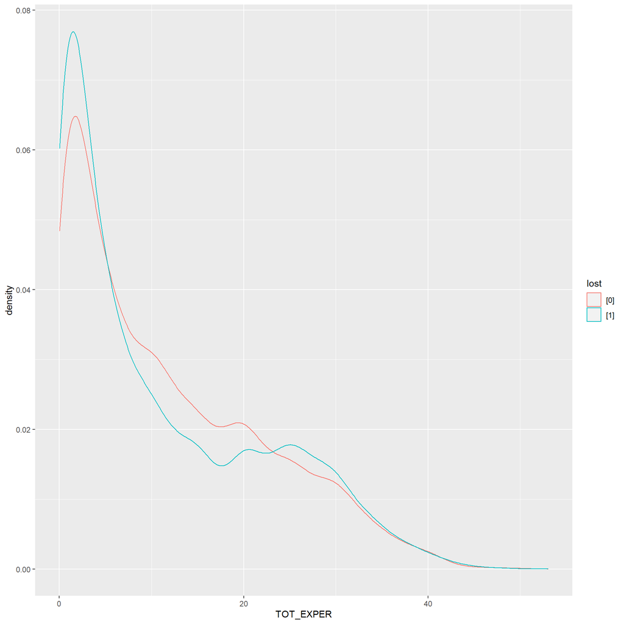

```r
ggplot(data=dCal) +
    geom_density(aes(x=TOT_EXPER,color=lost))
```

The no clear separation on double density plot

### Variable selection

1. calculate AIC for each variable
2. Use AIC mines null mode AIC and time 2
3. if the AIC improvement larger than than an value(our is 50), the store valiables

```r
selVars <- c()
minStep <- 50

for(v in catVars) {
    pred <- paste(outcome, 'pred', v, sep='_')
    liCheck <- 2*((logLikelyhood(dCal[, outcome], dCal[, pred]) - baseRateCheck))
    if(liCheck >= minStep) {
        print(sprintf("%s, calibrationScore: %g", v,liCheck))
        selVars     <- c(selVars, v)
    }
}
```

```
## [1] "SUBUNIT, calibrationScore: 135.358"
## [1] "DEGREE_INJURY, calibrationScore: 3695.8"
## [1] "UG_LOCATION, calibrationScore: 489.478"
## [1] "UG_MINING_METHOD, calibrationScore: 106.595"
## [1] "CLASSIFICATION, calibrationScore: 2850.99"
## [1] "ACCIDENT_TYPE, calibrationScore: 5261.19"
## [1] "OCCUPATION, calibrationScore: 2973.4"
## [1] "ACTIVITY, calibrationScore: 3363.24"
## [1] "INJURY_SOURCE, calibrationScore: 4269.23"
## [1] "NATURE_INJURY, calibrationScore: 6378.09"
## [1] "INJ_BODY_PART, calibrationScore: 5736.91"
## [1] "Minerals, calibrationScore: 56.0719"
```

```r
cat("\n Numerical variable \n\n")
```

```
##
##  Numerical variable
```

```r
for(v in numVars) {
    pred <- paste(outcome, 'pred', v, sep='_')
    liCheck <- 2*((logLikelyhood(dCal[,outcome], dCal[, pred]) - baseRateCheck) - 1)
    if(liCheck >= minStep) {
        print(sprintf("%s, calibrationScore: %g", v, liCheck))
        selVars     <- c(selVars, v)
    }
}
```

```
## [1] "ACCIDENT_TIME, calibrationScore: 112.389"
## [1] "NO_INJURIES, calibrationScore: 3280.59"
## [1] "TOT_EXPER, calibrationScore: 246.089"
## [1] "MINE_EXPER, calibrationScore: 179.565"
## [1] "JOB_EXPER, calibrationScore: 181.395"
## [1] "hours, calibrationScore: 147.989"
```

```r
cat('\n ALl variables')
```

```
##
##  ALl variables
```

```r
selVars
```

```
##  [1] "SUBUNIT"          "DEGREE_INJURY"    "UG_LOCATION"      "UG_MINING_METHOD"
##  [5] "CLASSIFICATION"   "ACCIDENT_TYPE"    "OCCUPATION"       "ACTIVITY"
##  [9] "INJURY_SOURCE"    "NATURE_INJURY"    "INJ_BODY_PART"    "Minerals"
## [13] "ACCIDENT_TIME"    "NO_INJURIES"      "TOT_EXPER"        "MINE_EXPER"
## [17] "JOB_EXPER"        "hours"
```

## Multivariate models

Functions for multivariate model performance evaluation.

```r
tradeOffsPlot <- function(df, modelName="model") {
    p1 <- ggplot(df, aes(x=threshold)) +
        geom_line(aes(y=precision)) +
        coord_cartesian(xlim = c(0, 1), ylim=c(0, 1) ) +
        ggtitle(paste(modelName, "trade-offs precision", sep=" "))

    p2 <- ggplot(df, aes(x=threshold)) +
        geom_line(aes(y=recall)) +
        coord_cartesian(xlim = c(0, 1) ) +
        ggtitle(paste(modelName, "trade-offs recall", sep=" "))
    grid.arrange(p1, p2, nrow = 2)
}

predictionQualityPlot <- function(df, by=predLabel, modelName="model") {
   ggplot(df, aes(x=preds, group=groups, color=groups, linetype=groups)) +
        geom_density() +
        ggtitle(paste(modelName, "Prediction Quality", sep=" "))
}

aucPlot <- function(df, modelName="model") {
    ggplot(df, aes(x=fpr, y=tpr, group=model, color=model, linetype=model))+
        geom_line() +
        geom_abline(slope = 1, linetype = "dashed") +
        labs(y = "True Positive Rate", x = "False Positive Rate") +
        ggtitle(paste(modelName, "auc", sep=" "))
}

trainAUCdf <- function(models, Data, trueValue, pos, posF, Type, modelName) {
    if(pos!=predLabel){
        predValue  <- predict(models, newdata=Data, type=Type)
    }else{
        predValue  <- predict(models, newdata=Data, type=Type)[, pos]
    }
    predObj    <- prediction(predValue, trueValue)
    perf       <- performance(predObj, "tpr", "fpr")
    return(list('df'=data.frame(fpr=unlist(perf@x.values), tpr=unlist(perf@y.values), model=modelName), AUC=performance(predObj, 'auc')@y.values ))
}
performancePlot <- function(models, Data, trueValue, trainData, trainTrueValue,
                    thresholdValue=0.5,
                    modelName="model",
                    Type='probability',
                    pos=predLabel,
                    posF=predLabelFalse,
                    plot = TRUE) {
    if(pos!=predLabel){
        predValue  <- predict(models, newdata=Data, type=Type)
    }else{
        predValue  <- predict(models, newdata=Data, type=Type)[, pos]
    }
    predObj    <- prediction(predValue, trueValue)
    precObj    <- performance(predObj, measure="prec")
    recObj     <- performance(predObj, measure="rec")

    precision  <- (precObj@y.values)[[1]]
    prec.x     <- (precObj@x.values)[[1]]
    recall     <- (recObj@y.values)[[1]]
    pnull      <- mean(trueValue==pos)

    perf       <- performance(predObj, "tpr", "fpr")
    df         <- data.frame('fpr'=unlist(perf@x.values), 'tpr'=unlist(perf@y.values), model=paste('Cal ', modelName, sep=""))
    rocDf      <- data.frame(threshold=prec.x, precision=precision, recall=recall)
    traindf <- trainAUCdf(models, trainData, trainTrueValue, pos, posF, Type, paste('Train', modelName, sep=' '))
    p <- aucPlot(rbind(df, traindf[[1]]), modelName)
    print(p)

    p <- predictionQualityPlot(data.frame('preds' = predValue, 'groups'=as.factor(trueValue)))
    print(p)

    p <- tradeOffsPlot(rocDf, modelName)
    print(p)

    cat('Confusion Matrix')
    ctab.test <- table(pred=ifelse(predValue>thresholdValue, pos, posF), true.values=trueValue)
    print(kable(ctab.test))

    cat('Classification Quality')
    pes <- ctab.test[2, 2] / sum(ctab.test[, 2])
    rcl <- ctab.test[2, 2] / sum(ctab.test[2, ])
    print(kable(data.frame(performance=c('precision', 'recall', 'F1', 'accuracy '),
                            percentage=c(pes,
                                        rcl,
                                        2*pes*rcl/(pes + rcl),
                                        (ctab.test[1,1]+ctab.test[2,2])/sum(ctab.test)))))


    print( paste('Model Log Likelihood:',logLikelyhood(trueValue, predValue)) )
    cat('\n')
    print( paste('Null Model Log Likelihood:', logLikelyhood(trueValue, pnull)) )

    return(list( 'DataFrame'=df, 'TrianAUC'=as.numeric(traindf[[2]]), "AUC"=as.numeric(performance(predObj, 'auc')@y.values), 'logLH'=logLikelyhood(trueValue, predValue) ))
}
```